# Location Recommender System

```python
import numpy as np # library to handle data in a vectorized manner
import pandas as pd # library for data analysis
import json # library to handle JSON files
from geopy.geocoders import Nominatim # convert an address into latitude and longitude values
from geopy.exc import GeocoderTimedOut
import requests # library to handle requests
from pandas.io.json import json_normalize # tranform JSON file into a pandas dataframe

# Visualization modules
import matplotlib.cm as cm
import matplotlib.colors as colors

# import k-means from clustering stage
from sklearn.cluster import KMeans
import folium # map rendering library
```

## Using New york City Neighbourhood

```python
with open('new_york_data.json') as json_data:
    newyork_data = json.load(json_data)
```

The attributes we need from this json file are :

1. Borough Name
2. Neighbourhood
3. Latitude
4. Longitude

we will make a pandas dataframe with the 4 columns as listed above but before making the dataframe we will extract what we need.

```python
newyork_df = pd.DataFrame(columns = ['Borough_name','Neighborhood','Latitude','Longitude'])
newyork_df
```

|  | Borough_name | Neighborhood | Latitude | Longitude |
| --- | --- | --- | --- | --- |

```python
newyork_data_clean = newyork_data['features']
for data in newyork_data_clean:

    neighborhood = data['properties']['name']
    borough = data['properties']['borough']
    location = data['geometry']['coordinates']
    longitude,latitude = location[0],location[1]
    data = {"Borough_name":borough,"Neighborhood":neighborhood,"Latitude":latitude,"Longitude":longitude}
    newyork_df = newyork_df.append(data,ignore_index=True)
```

```python
newyork_df.head()
```

|  | Borough_name | Neighborhood | Latitude | Longitude |
| --- | --- | --- | --- | --- |
| 0 | Bronx | Wakefield | 40.894705 | -73.847201 |
| 1 | Bronx | Co-op City | 40.874294 | -73.829939 |
| 2 | Bronx | Eastchester | 40.887556 | -73.827806 |
| 3 | Bronx | Fieldston | 40.895437 | -73.905643 |
| 4 | Bronx | Riverdale | 40.890834 | -73.912585 |

```python
newyork_df['Borough_name'].value_counts()
```

```
Queens           81
Brooklyn         70
Staten Island    63
Bronx            52
Manhattan        40
Name: Borough_name, dtype: int64
```

```python
newyork_df.shape
```

```
(306, 4)
```

> The dataframe consists of Five Boroughs and 306 Neighborhoods.

## Geopy library into action!

```python
address = 'New York City, NY'

geolocator = Nominatim(user_agent="ny_explorer")
try:
    location = geolocator.geocode(address)
    latitude = location.latitude
    longitude = location.longitude
    print('The geograpical coordinate of New York City are {}, {}.'.format(latitude, longitude))
except GeocoderTimedOut as e:
    print("Error: geocode failed on input %s with message %s"%(my_address, e.message))
```

```
The geograpical coordinate of New York City are 40.7127281, -74.0060152.
```

## Creating a map of New York City with neighborhoods superimposed on top.

```python
# create map of New York using latitude and longitude values
map_newyork = folium.Map(location=[latitude, longitude], zoom_start=10)

# add markers to map
for lat, lng, borough, neighborhood in zip(newyork_df['Latitude'], newyork_df['Longitude'], newyork_df['Borough_name'], newyork_df['Neighborhood']):
    label = '{}, {}'.format(neighborhood, borough)
    label = folium.Popup(label, parse_html=True)
    folium.CircleMarker(
        [lat, lng],
        radius=5,
        popup=label,
        color='blue',
        fill=True,
        fill_color='#3186cc',
        fill_opacity=0.7,
        parse_html=False).add_to(map_newyork)

map_newyork
```

[interactive chart not shown]

## Let's look into Manhattan Borough.

```python
manhattan_data = newyork_df[newyork_df['Borough_name'] == 'Manhattan'].reset_index(drop=True)
```

Let's get the geographical coordinates of Manhattan.

```python
address = 'Manhattan, NY'

geolocator = Nominatim(user_agent="ny_explorer")
try:
    location = geolocator.geocode(address)
    latitude = location.latitude
    longitude = location.longitude
    print('The geograpical coordinate of Manhattan are {}, {}.'.format(latitude, longitude))
except GeocoderTimedOut as e:
    print("Error: geocode failed on input %s with message %s"%(my_address, e.message))
```

```
The geograpical coordinate of Manhattan are 40.7896239, -73.9598939.
```

```python
# create map of Manhattan using latitude and longitude values
map_manhattan = folium.Map(location=[latitude, longitude], zoom_start=11)

# add markers to map
for lat, lng, label in zip(manhattan_data['Latitude'], manhattan_data['Longitude'], manhattan_data['Neighborhood']):
    label = folium.Popup(label, parse_html=True)
    folium.CircleMarker(
        [lat, lng],
        radius=5,
        popup=label,
        color='blue',
        fill=True,
        fill_color='#3186cc',
        fill_opacity=0.7,
        parse_html=False).add_to(map_manhattan)

map_manhattan
```

[interactive chart not shown]

## Let's explore the first neighborhood in Manhattan Borough.

```python
manhattan_data.loc[0, 'Neighborhood']
```

```
'Marble Hill'
```

- Get the neighborhood's latitude and longitude values.

```python
neighborhood_latitude = manhattan_data.loc[0, 'Latitude'] # neighborhood latitude value
neighborhood_longitude = manhattan_data.loc[0, 'Longitude'] # neighborhood longitude value

neighborhood_name = manhattan_data.loc[0, 'Neighborhood'] # neighborhood name

print('Latitude and longitude values of {} are {}, {}.'.format(neighborhood_name,
                                                               neighborhood_latitude,
                                                               neighborhood_longitude))
```

```
Latitude and longitude values of Marble Hill are 40.87655077879964, -73.91065965862981.
```

- Now, let's get the top 100 venues that are in Marble Hill within a radius of 1000 meters.

Define Foursquare Credentials and Version.

```python
with open("apikeys.json",'r') as api_file:
    data = json.load(api_file)
    CLIENT_ID = data["CLIENT_ID"] # your Foursquare ID
    CLIENT_SECRET = data["CLIENT_SECRET"] # your Foursquare Secret
    VERSION = data["VERSION"]
```

```python
LIMIT = 100 # limit of number of venues returned by Foursquare API
radius = 1000 # define radius
# create URL
url = 'https://api.foursquare.com/v2/venues/explore?&client_id={}&client_secret={}&v={}&ll={},{}&radius={}&limit={}'.format(
    CLIENT_ID,
    CLIENT_SECRET,
    VERSION,
    neighborhood_latitude,
    neighborhood_longitude,
    radius,
    LIMIT)
url # display URL
```

```
'https://api.foursquare.com/v2/venues/explore?&client_id=I4D4A1JPPOZV3TKA0ZQ12JORYAAAMWRIK5D5K1THXH5LECKU&client_secret=2MWZDT2HP0NODCSYOQHM3YDBMTJI3SUGGT3XE5GPHINMCZRC&v=20190604&ll=40.87655077879964,-73.91065965862981&radius=1000&limit=100'
```

```python
results = requests.get(url).json()
```

```python
manhattan_venues = pd.DataFrame(columns = ["Venue", "Latitude","Longitude","Address","Category"])
manhattan_venues
```

|  | Venue | Latitude | Longitude | Address | Category |
| --- | --- | --- | --- | --- | --- |

```python
venues = results['response']['groups'][0]['items']

nearby_venues = json_normalize(venues) # flatten JSON
```

- We have our information in 'Venue.name' ,'venue.categories', 'venue.location.lat', 'venue.location.lng', "venue.location.formattedAddress". We have to write a function to extract the Venue Category.

```python
# function that extracts the category of the venue
def get_category_type(row):

    categories_list = row['venue.categories']

    if len(categories_list) == 0:
        return None
    else:
        return categories_list[0]['name']
```

```python
# filter columns
filtered_columns = ['venue.name', 'venue.categories', 'venue.location.lat', 'venue.location.lng']
nearby_venues =nearby_venues.loc[:, filtered_columns]

# filter the category for each row
nearby_venues['venue.categories'] = nearby_venues.apply(get_category_type, axis=1)
```

```python
nearby_venues.head()
```

|  | venue.name | venue.categories | venue.location.lat | venue.location.lng |
| --- | --- | --- | --- | --- |
| 0 | Bikram Yoga | Yoga Studio | 40.876844 | -73.906204 |
| 1 | Arturo's | Pizza Place | 40.874412 | -73.910271 |
| 2 | Tibbett Diner | Diner | 40.880404 | -73.908937 |
| 3 | Sam's Pizza | Pizza Place | 40.879435 | -73.905859 |
| 4 | Starbucks | Coffee Shop | 40.877531 | -73.905582 |

```python
print('{} venues were returned by Foursquare.'.format(nearby_venues.shape[0]))
```

```
83 venues were returned by Foursquare.
```

# Similarly let's extract venues for all the neighbourhoods in Newyork City.

Let's create a function to repeat the same process to all the neighborhoods in each Borough.

```python
def getNearbyVenues(borough,names, latitudes, longitudes, radius=500):

    venues_list=[]
    for name, lat, lng in zip(names, latitudes, longitudes):
#         print(name)

        # create the API request URL
        url = 'https://api.foursquare.com/v2/venues/explore?&client_id={}&client_secret={}&v={}&ll={},{}&radius={}&limit={}'.format(
            CLIENT_ID,
            CLIENT_SECRET,
            VERSION,
            lat,
            lng,
            radius,
            LIMIT)

        # make the GET request
        results = requests.get(url).json()
        #print(results)
        results = results["response"]["groups"][0]["items"]

        # return only relevant information for each nearby venue

        venues_list.append([(
            borough,
            name,
            lat,
            lng,
            v['venue']['name'],
            v['venue']['location']['lat'],
            v['venue']['location']['lng'],
            v['venue']['categories'][0]['name']
            ) for v in results])

    nearby_venues = pd.DataFrame([item for venue_list in venues_list for item in venue_list])

    nearby_venues.columns = ['Borough','Neighborhood',
                  'Neighborhood Latitude',
                  'Neighborhood Longitude',
                  'Venue',
                  'Venue Latitude',
                  'Venue Longitude',
                  'Venue Category']
    return(nearby_venues)
```

```python
boroughs = newyork_df['Borough_name'].unique().tolist()
```

```python
boroughs
```

```
['Bronx', 'Manhattan', 'Brooklyn', 'Queens', 'Staten Island']
```

```python
Master_df = pd.DataFrame(columns = ['Borough','Neighborhood',
                  'Neighborhood Latitude',
                  'Neighborhood Longitude',
                  'Venue',
                  'Venue Latitude',
                  'Venue Longitude',
                  'Venue Category'])
borough = boroughs[0]
print('Finding Venues around {} '.format(borough))
borough_data = newyork_df[newyork_df['Borough_name'] == borough].reset_index(drop=True)
    #print(borough_data.head())
borough_venues = getNearbyVenues(borough,names=borough_data['Neighborhood'],
                                   latitudes=borough_data['Latitude'],
                                   longitudes=borough_data['Longitude']
                                  )
Master_df = Master_df.append(borough_venues,ignore_index = True)
print("Master DataFrame ready with all the venues from all the neighbourhoods from {}".format(borough))
# print('Concatenated {}_venues dataframe to Master dataframe'.format(borough))
print("....................................................................")
```

```
Finding Venues around Bronx
Master DataFrame ready with all the venues from all the neighbourhoods from Bronx
....................................................................
```

```python
borough = boroughs[1]
print('Finding Venues around {} '.format(borough))
borough_data = newyork_df[newyork_df['Borough_name'] == borough].reset_index(drop=True)
    #print(borough_data.head())
borough_venues = getNearbyVenues(borough,names=borough_data['Neighborhood'],
                                   latitudes=borough_data['Latitude'],
                                   longitudes=borough_data['Longitude']
                                  )
Master_df = Master_df.append(borough_venues,ignore_index = True)

print("Master DataFrame ready with all the venues from all the neighbourhoods from {}".format(borough))
print("....................................................................")
```

```
Finding Venues around Manhattan
Master DataFrame ready with all the venues from all the neighbourhoods from Manhattan
....................................................................
```

```python
borough = boroughs[2]
print('Finding Venues around {} '.format(borough))
borough_data = newyork_df[newyork_df['Borough_name'] == borough].reset_index(drop=True)
    #print(borough_data.head())
borough_venues = getNearbyVenues(borough,names=borough_data['Neighborhood'],
                                   latitudes=borough_data['Latitude'],
                                   longitudes=borough_data['Longitude']
                                  )
Master_df = Master_df.append(borough_venues,ignore_index = True)

print("Master DataFrame ready with all the venues from all the neighbourhoods from {}".format(borough))
print("....................................................................")
```

```
Finding Venues around Brooklyn
Master DataFrame ready with all the venues from all the neighbourhoods from Brooklyn
....................................................................
```

```python
borough = boroughs[3]
print('Finding Venues around {} '.format(borough))
borough_data = newyork_df[newyork_df['Borough_name'] == borough].reset_index(drop=True)
    #print(borough_data.head())
borough_venues = getNearbyVenues(borough,names=borough_data['Neighborhood'],
                                   latitudes=borough_data['Latitude'],
                                   longitudes=borough_data['Longitude']
                                  )
Master_df = Master_df.append(borough_venues,ignore_index = True)

print("Master DataFrame ready with all the venues from all the neighbourhoods from {}".format(borough))
print("....................................................................")
```

```
Finding Venues around Queens
Master DataFrame ready with all the venues from all the neighbourhoods from Queens
....................................................................
```

```python
borough = boroughs[4]
print('Finding Venues around {} '.format(borough))
borough_data = newyork_df[newyork_df['Borough_name'] == borough].reset_index(drop=True)
    #print(borough_data.head())
borough_venues = getNearbyVenues(borough,names=borough_data['Neighborhood'],
                                   latitudes=borough_data['Latitude'],
                                   longitudes=borough_data['Longitude']
                                  )
Master_df = Master_df.append(borough_venues,ignore_index = True)

print("Master DataFrame ready with all the venues from all the neighbourhoods from {}".format(borough))
print("....................................................................")
```

```
Finding Venues around Staten Island
Master DataFrame ready with all the venues from all the neighbourhoods from Staten Island
....................................................................
```

### Master DataFrame consists of all neighbourboods of all boroughs with nearest venues,It's Name,locations and Category.

```python
Master_df.to_csv("Master.csv")
```

```python
Master_df = pd.read_csv("Master.csv")
```

```python
Master_df.drop(columns = 'Unnamed: 0',inplace = True,axis = 1)
```

```python
Master_df.head()
```

|  | Borough | Neighborhood | Neighborhood Latitude | Neighborhood Longitude | Venue | Venue Latitude | Venue Longitude | Venue Category |
| --- | --- | --- | --- | --- | --- | --- | --- | --- |
| 0 | Bronx | Wakefield | 40.894705 | -73.847201 | Lollipops Gelato | 40.894123 | -73.845892 | Dessert Shop |
| 1 | Bronx | Wakefield | 40.894705 | -73.847201 | Rite Aid | 40.896649 | -73.844846 | Pharmacy |
| 2 | Bronx | Wakefield | 40.894705 | -73.847201 | Carvel Ice Cream | 40.890487 | -73.848568 | Ice Cream Shop |
| 3 | Bronx | Wakefield | 40.894705 | -73.847201 | Dunkin' | 40.890459 | -73.849089 | Donut Shop |
| 4 | Bronx | Wakefield | 40.894705 | -73.847201 | Shell | 40.894187 | -73.845862 | Gas Station |

## Use Case: Suppose you want to start a Car rental business, let's see which areas are suitable.

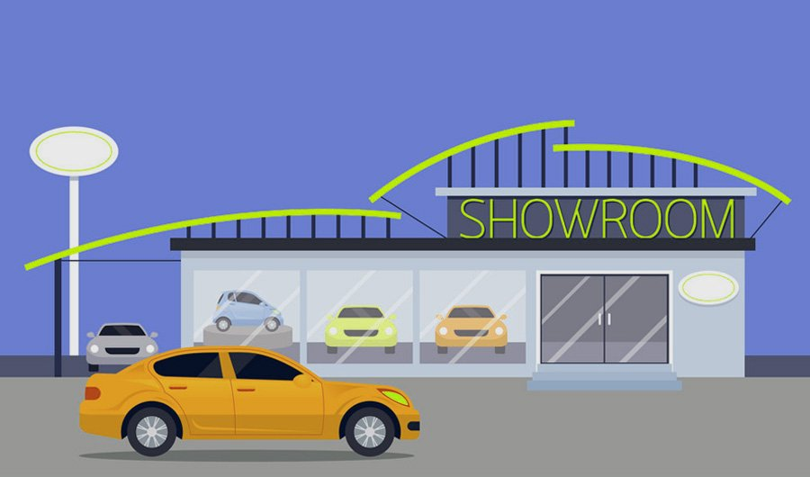

```python
car_df = Master_df[Master_df['Venue Category'].str.contains('[Cc]ar')]
```

```python
car_df.head()
```

|  | Borough | Neighborhood | Neighborhood Latitude | Neighborhood Longitude | Venue | Venue Latitude | Venue Longitude | Venue Category |
| --- | --- | --- | --- | --- | --- | --- | --- | --- |
| 5 | Bronx | Wakefield | 40.894705 | -73.847201 | Cooler Runnings Jamaican Restaurant Inc | 40.898083 | -73.850259 | Caribbean Restaurant |
| 26 | Bronx | Eastchester | 40.887556 | -73.827806 | Fish & Ting | 40.885656 | -73.829197 | Caribbean Restaurant |
| 31 | Bronx | Eastchester | 40.887556 | -73.827806 | Golden Krust Caribbean Restaurant | 40.888488 | -73.831083 | Caribbean Restaurant |
| 33 | Bronx | Eastchester | 40.887556 | -73.827806 | Royal Caribbean Bakery | 40.888249 | -73.831661 | Caribbean Restaurant |
| 64 | Bronx | Kingsbridge | 40.881687 | -73.902818 | El Malecon | 40.879338 | -73.904457 | Caribbean Restaurant |

```python
car_df['Venue Category'].unique()
```

```
array(['Caribbean Restaurant', 'Rental Car Location'], dtype=object)
```

```python
rental_car = car_df[car_df['Venue Category'] == 'Rental Car Location']
```

```python
rental_car.head()
```

|  | Borough | Neighborhood | Neighborhood Latitude | Neighborhood Longitude | Venue | Venue Latitude | Venue Longitude | Venue Category |
| --- | --- | --- | --- | --- | --- | --- | --- | --- |
| 95 | Bronx | Kingsbridge | 40.881687 | -73.902818 | Enterprise Rent-A-Car | 40.879866 | -73.903847 | Rental Car Location |
| 134 | Bronx | Woodlawn | 40.898273 | -73.867315 | Enterprise Rent-A-Car | 40.896091 | -73.865364 | Rental Car Location |
| 796 | Bronx | Belmont | 40.857277 | -73.888452 | Enterprise Rent-A-Car | 40.858491 | -73.884325 | Rental Car Location |
| 1007 | Bronx | Concourse | 40.834284 | -73.915589 | Zipcar Grand Concourse & 165 St | 40.831150 | -73.919762 | Rental Car Location |
| 1453 | Brooklyn | Greenpoint | 40.730201 | -73.954241 | Enterprise Rent-A-Car | 40.731487 | -73.951335 | Rental Car Location |

```python
rental_car.shape
```

```
(16, 8)
```

## Let's Visualize these locations on a map.

```python
from folium import plugins
m = folium.Map([40.7127281, -74.0060152], zoom_start=11)
# mark each station as a point
for index, row in rental_car.iterrows():
    folium.CircleMarker([row['Venue Latitude'], row['Venue Longitude']],
                        radius=2,
                        popup=row['Venue'],
                        fill_color="#3db7e4", # divvy color
                       ).add_to(m)
# convert to (n, 2) nd-array format for heatmap
CarArr = rental_car[['Venue Latitude', 'Venue Longitude']].as_matrix()

# plot heatmap
m.add_children(plugins.HeatMap(CarArr, radius=15))
m
```

[interactive chart not shown]

- The number of rental car businesses are 16 in entire Newyork city and Neighbourhood Stein way has the highest number of rental car shops.

### Let's visualize using pins than dots.

```python
for index, row in rental_car.iterrows():
    folium.Marker([row['Neighborhood Latitude'], row['Neighborhood Longitude']],
                        radius=2,
                        popup=row['Neighborhood'],
                       ).add_to(m)
m
```

[interactive chart not shown]

### Let's explore venues around these neighborhoods and see if we can get some insights.

```python
borough_data = rental_car
    #print(borough_data.head())
car_rental_venues = getNearbyVenues(borough,names=borough_data['Neighborhood'],
                                   latitudes=borough_data['Neighborhood Latitude'],
                                   longitudes=borough_data['Neighborhood Longitude']
                                  )


print("Found all Venues in those neighborhoods where there are car rental businesses.")
print("....................................................................")
```

```
Found all Venues in those neighborhoods where there are car rental businesses.
....................................................................
```

```python
car_rental_venues.head()
```

|  | Borough | Neighborhood | Neighborhood Latitude | Neighborhood Longitude | Venue | Venue Latitude | Venue Longitude | Venue Category |
| --- | --- | --- | --- | --- | --- | --- | --- | --- |
| 0 | Staten Island | Kingsbridge | 40.881687 | -73.902818 | Garden Gourmet Market | 40.881350 | -73.903389 | Gourmet Shop |
| 1 | Staten Island | Kingsbridge | 40.881687 | -73.902818 | Leche y Miel | 40.883742 | -73.901857 | Latin American Restaurant |
| 2 | Staten Island | Kingsbridge | 40.881687 | -73.902818 | Kingsbridge Social Club | 40.884545 | -73.901964 | Pizza Place |
| 3 | Staten Island | Kingsbridge | 40.881687 | -73.902818 | El Malecon | 40.879338 | -73.904457 | Caribbean Restaurant |
| 4 | Staten Island | Kingsbridge | 40.881687 | -73.902818 | Sam's Pizza | 40.879435 | -73.905859 | Pizza Place |

```python
car_rental_venues_onehot = pd.get_dummies(car_rental_venues[['Venue Category']], prefix="", prefix_sep="")

# add neighborhood column back to dataframe
car_rental_venues_onehot['Neighborhood'] = car_rental_venues['Neighborhood']

# move neighborhood column to the first column
fixed_columns = [car_rental_venues_onehot.columns[-1]] + list(car_rental_venues_onehot.columns[:-1])
car_rental_venues_onehot = car_rental_venues_onehot[fixed_columns]

car_rental_venues_onehot.head()
```

|  | Neighborhood | Accessories Store | American Restaurant | Antique Shop | Arepa Restaurant | Argentinian Restaurant | Art Gallery | Arts & Crafts Store | Asian Restaurant | Athletics & Sports | Auto Workshop | BBQ Joint | Bagel Shop | Bakery | Bank | Bar | Beer Bar | Beer Store | Bike Rental / Bike Share | Boat or Ferry | Bookstore | Boutique | Boxing Gym | Breakfast Spot | Brewery | Bubble Tea Shop | Buffet | Burger Joint | Burrito Place | … |
| --- | --- | --- | --- | --- | --- | --- | --- | --- | --- | --- | --- | --- | --- | --- | --- | --- | --- | --- | --- | --- | --- | --- | --- | --- | --- | --- | --- | --- | --- | --- |
| 0 | Kingsbridge | 0 | 0 | 0 | 0 | 0 | 0 | 0 | 0 | 0 | 0 | 0 | 0 | 0 | 0 | 0 | 0 | 0 | 0 | 0 | 0 | 0 | 0 | 0 | 0 | 0 | 0 | 0 | 0 | … |
| 1 | Kingsbridge | 0 | 0 | 0 | 0 | 0 | 0 | 0 | 0 | 0 | 0 | 0 | 0 | 0 | 0 | 0 | 0 | 0 | 0 | 0 | 0 | 0 | 0 | 0 | 0 | 0 | 0 | 0 | 0 | … |
| 2 | Kingsbridge | 0 | 0 | 0 | 0 | 0 | 0 | 0 | 0 | 0 | 0 | 0 | 0 | 0 | 0 | 0 | 0 | 0 | 0 | 0 | 0 | 0 | 0 | 0 | 0 | 0 | 0 | 0 | 0 | … |
| 3 | Kingsbridge | 0 | 0 | 0 | 0 | 0 | 0 | 0 | 0 | 0 | 0 | 0 | 0 | 0 | 0 | 0 | 0 | 0 | 0 | 0 | 0 | 0 | 0 | 0 | 0 | 0 | 0 | 0 | 0 | … |
| 4 | Kingsbridge | 0 | 0 | 0 | 0 | 0 | 0 | 0 | 0 | 0 | 0 | 0 | 0 | 0 | 0 | 0 | 0 | 0 | 0 | 0 | 0 | 0 | 0 | 0 | 0 | 0 | 0 | 0 | 0 | … |

### Next, let's group rows by neighborhood and by taking the mean of the frequency of occurrence of each category.

```python
car_grouped = car_rental_venues_onehot.groupby('Neighborhood').mean().reset_index()
car_grouped.head()
```

|  | Neighborhood | Accessories Store | American Restaurant | Antique Shop | Arepa Restaurant | Argentinian Restaurant | Art Gallery | Arts & Crafts Store | Asian Restaurant | Athletics & Sports | Auto Workshop | BBQ Joint | Bagel Shop | Bakery | Bank | Bar | Beer Bar | Beer Store | Bike Rental / Bike Share | Boat or Ferry | Bookstore | Boutique | Boxing Gym | Breakfast Spot | Brewery | Bubble Tea Shop | Buffet | Burger Joint | Burrito Place | … |
| --- | --- | --- | --- | --- | --- | --- | --- | --- | --- | --- | --- | --- | --- | --- | --- | --- | --- | --- | --- | --- | --- | --- | --- | --- | --- | --- | --- | --- | --- | --- |
| 0 | Bath Beach | 0.0 | 0.000000 | 0.000000 | 0.0 | 0.0 | 0.000000 | 0.000000 | 0.021277 | 0.000000 | 0.000000 | 0.0 | 0.000000 | 0.021277 | 0.021277 | 0.000000 | 0.0 | 0.0 | 0.021277 | 0.0 | 0.000000 | 0.000000 | 0.000000 | 0.0 | 0.0 | 0.042553 | 0.000000 | 0.021277 | 0.000000 | … |
| 1 | Belmont | 0.0 | 0.010000 | 0.000000 | 0.0 | 0.0 | 0.000000 | 0.000000 | 0.000000 | 0.000000 | 0.000000 | 0.0 | 0.000000 | 0.050000 | 0.030000 | 0.020000 | 0.0 | 0.0 | 0.000000 | 0.0 | 0.000000 | 0.000000 | 0.000000 | 0.0 | 0.0 | 0.000000 | 0.000000 | 0.000000 | 0.000000 | … |
| 2 | Boerum Hill | 0.0 | 0.011364 | 0.011364 | 0.0 | 0.0 | 0.000000 | 0.022727 | 0.000000 | 0.011364 | 0.000000 | 0.0 | 0.000000 | 0.022727 | 0.011364 | 0.034091 | 0.0 | 0.0 | 0.000000 | 0.0 | 0.011364 | 0.011364 | 0.000000 | 0.0 | 0.0 | 0.011364 | 0.000000 | 0.011364 | 0.011364 | … |
| 3 | Clinton Hill | 0.0 | 0.000000 | 0.000000 | 0.0 | 0.0 | 0.010753 | 0.021505 | 0.000000 | 0.000000 | 0.010753 | 0.0 | 0.021505 | 0.010753 | 0.010753 | 0.010753 | 0.0 | 0.0 | 0.021505 | 0.0 | 0.000000 | 0.010753 | 0.010753 | 0.0 | 0.0 | 0.000000 | 0.000000 | 0.010753 | 0.000000 | … |
| 4 | College Point | 0.0 | 0.000000 | 0.000000 | 0.0 | 0.0 | 0.000000 | 0.000000 | 0.069767 | 0.000000 | 0.000000 | 0.0 | 0.000000 | 0.046512 | 0.023256 | 0.046512 | 0.0 | 0.0 | 0.000000 | 0.0 | 0.000000 | 0.000000 | 0.000000 | 0.0 | 0.0 | 0.000000 | 0.023256 | 0.000000 | 0.023256 | … |

## Let's print each neighborhood along with the top 5 most common venues.

```python
num_top_venues = 5

for hood in car_grouped['Neighborhood']:
    print("----"+hood+"----")
    temp = car_grouped[car_grouped['Neighborhood'] == hood].T.reset_index()
    temp.columns = ['venue','freq']
    temp = temp.iloc[1:]
    temp['freq'] = temp['freq'].astype(float)
    temp = temp.round({'freq': 2})
    print(temp.sort_values('freq', ascending=False).reset_index(drop=True).head(num_top_venues))
    print('\n')
```

```
----Bath Beach----
                venue  freq
0            Pharmacy  0.09
1  Chinese Restaurant  0.06
2         Pizza Place  0.04
3          Kids Store  0.04
4  Italian Restaurant  0.04


----Belmont----
                venue  freq
0  Italian Restaurant  0.18
1         Pizza Place  0.09
2       Deli / Bodega  0.08
3              Bakery  0.05
4                Bank  0.03


----Boerum Hill----
               venue  freq
0       Dance Studio  0.05
1        Coffee Shop  0.05
2                Bar  0.03
3                Spa  0.03
4  French Restaurant  0.03


----Clinton Hill----
                venue  freq
0  Italian Restaurant  0.05
1         Pizza Place  0.05
2  Mexican Restaurant  0.04
3   Indian Restaurant  0.03
4     Thai Restaurant  0.03


----College Point----
                       venue  freq
0                Pizza Place  0.09
1              Deli / Bodega  0.09
```

[output cut: 114 more lines]

```
                  venue  freq
0  Fast Food Restaurant  0.14
1                 Field  0.05
2             Juice Bar  0.05
3              Pharmacy  0.05
4                  Café  0.05


----Woodlawn----
           venue  freq
0  Deli / Bodega  0.14
1    Pizza Place  0.10
2     Playground  0.07
3            Pub  0.07
4          Plaza  0.03
```

### The Neighborhoods **Steinway** and **East Elmhurst** are the ones which has **Rental Car Business** in the top 5 venues. Let's group all the neighborhoods and find the Neighborhood which is similar to Steinway and East Elmhurst.

- Now let's create the new dataframe and display the top 10 venues for each neighborhood.

```python
newyork_venues_onehot = pd.get_dummies(Master_df[['Venue Category']], prefix="", prefix_sep="")

# add neighborhood column back to dataframe
newyork_venues_onehot['Neighborhood'] = Master_df['Neighborhood']

# move neighborhood column to the first column
fixed_columns = [newyork_venues_onehot.columns[-1]] + list(newyork_venues_onehot.columns[:-1])
newyork_venues_onehot = newyork_venues_onehot[fixed_columns]

print("One hot encoding for Mastet dataframe is done..........................................................................")

new_york_grouped = newyork_venues_onehot.groupby('Neighborhood').mean().reset_index()

print("dataframe is grouped based on Neighborhood column and mean function is applied to all columns..........................")
```

```
One hot encoding for Mastet dataframe is done..........................................................................
dataframe is grouped based on Neighborhood column and mean function is applied to all columns..........................
```

```python
def return_most_common_venues(row, num_top_venues):
    row_categories = row.iloc[1:]
    row_categories_sorted = row_categories.sort_values(ascending=False)

    return row_categories_sorted.index.values[0:num_top_venues]
```

```python
indicators = ['st', 'nd', 'rd']
num_top_venues = 10
# create columns according to number of top venues
columns = ['Neighborhood']
for ind in np.arange(num_top_venues):
    try:
        columns.append('{}{} Most Common Venue'.format(ind+1, indicators[ind]))
    except:
        columns.append('{}th Most Common Venue'.format(ind+1))

# create a new dataframe
neighborhoods_venues_sorted = pd.DataFrame(columns=columns)
neighborhoods_venues_sorted['Neighborhood'] = new_york_grouped['Neighborhood']

for ind in np.arange(new_york_grouped.shape[0]):
    neighborhoods_venues_sorted.iloc[ind, 1:] = return_most_common_venues(new_york_grouped.iloc[ind, :], num_top_venues)

neighborhoods_venues_sorted.head()
```

|  | Neighborhood | 1st Most Common Venue | 2nd Most Common Venue | 3rd Most Common Venue | 4th Most Common Venue | 5th Most Common Venue | 6th Most Common Venue | 7th Most Common Venue | 8th Most Common Venue | 9th Most Common Venue | 10th Most Common Venue |
| --- | --- | --- | --- | --- | --- | --- | --- | --- | --- | --- | --- |
| 0 | Allerton | Pizza Place | Chinese Restaurant | Bus Station | Deli / Bodega | Supermarket | Intersection | Bike Trail | Breakfast Spot | Gas Station | Dessert Shop |
| 1 | Annadale | Pizza Place | Restaurant | Diner | Park | Liquor Store | Pharmacy | Train Station | American Restaurant | Sports Bar | Dance Studio |
| 2 | Arden Heights | Deli / Bodega | Pharmacy | Coffee Shop | Bus Stop | Pizza Place | Women's Store | Flower Shop | Fast Food Restaurant | Field | Filipino Restaurant |
| 3 | Arlington | Bus Stop | Boat or Ferry | Grocery Store | Deli / Bodega | Intersection | American Restaurant | Field | Filipino Restaurant | Fish & Chips Shop | Fish Market |
| 4 | Arrochar | Deli / Bodega | Bagel Shop | Italian Restaurant | Bus Stop | Athletics & Sports | Hotel | Liquor Store | Outdoors & Recreation | Mediterranean Restaurant | Pizza Place |

```python
neighborhoods_venues_sorted.shape[0]
```

```
263
```

# Cluster Neighborhoods.

```python
# set number of clusters
kclusters = 5

new_york_grouped_clustering = new_york_grouped.drop('Neighborhood', 1)

# run k-means clustering
kmeans = KMeans(n_clusters=kclusters, random_state=42).fit(new_york_grouped_clustering)

# check cluster labels generated for each row in the dataframe
kmeans.labels_[0:10]
```

```
array([1, 1, 2, 2, 2, 1, 1, 1, 1, 1], dtype=int32)
```

```python
# add clustering labels
neighborhoods_venues_sorted.insert(0, 'Cluster Labels', kmeans.labels_)

newyork_merged = Master_df

# merge toronto_grouped with toronto_data to add latitude/longitude for each neighborhood
newyork_merged = newyork_merged.join(neighborhoods_venues_sorted.set_index('Neighborhood'), on='Neighborhood')

newyork_merged.head() # check the last columns!
```

|  | Borough | Neighborhood | Neighborhood Latitude | Neighborhood Longitude | Venue | Venue Latitude | Venue Longitude | Venue Category | Cluster Labels | 1st Most Common Venue | 2nd Most Common Venue | 3rd Most Common Venue | 4th Most Common Venue | 5th Most Common Venue | 6th Most Common Venue | 7th Most Common Venue | 8th Most Common Venue | 9th Most Common Venue | 10th Most Common Venue |
| --- | --- | --- | --- | --- | --- | --- | --- | --- | --- | --- | --- | --- | --- | --- | --- | --- | --- | --- | --- |
| 0 | Bronx | Wakefield | 40.894705 | -73.847201 | Lollipops Gelato | 40.894123 | -73.845892 | Dessert Shop | 1 | Pharmacy | Ice Cream Shop | Caribbean Restaurant | Sandwich Place | Donut Shop | Laundromat | Dessert Shop | Gas Station | French Restaurant | Farmers Market |
| 1 | Bronx | Wakefield | 40.894705 | -73.847201 | Rite Aid | 40.896649 | -73.844846 | Pharmacy | 1 | Pharmacy | Ice Cream Shop | Caribbean Restaurant | Sandwich Place | Donut Shop | Laundromat | Dessert Shop | Gas Station | French Restaurant | Farmers Market |
| 2 | Bronx | Wakefield | 40.894705 | -73.847201 | Carvel Ice Cream | 40.890487 | -73.848568 | Ice Cream Shop | 1 | Pharmacy | Ice Cream Shop | Caribbean Restaurant | Sandwich Place | Donut Shop | Laundromat | Dessert Shop | Gas Station | French Restaurant | Farmers Market |
| 3 | Bronx | Wakefield | 40.894705 | -73.847201 | Dunkin' | 40.890459 | -73.849089 | Donut Shop | 1 | Pharmacy | Ice Cream Shop | Caribbean Restaurant | Sandwich Place | Donut Shop | Laundromat | Dessert Shop | Gas Station | French Restaurant | Farmers Market |
| 4 | Bronx | Wakefield | 40.894705 | -73.847201 | Shell | 40.894187 | -73.845862 | Gas Station | 1 | Pharmacy | Ice Cream Shop | Caribbean Restaurant | Sandwich Place | Donut Shop | Laundromat | Dessert Shop | Gas Station | French Restaurant | Farmers Market |

# Let's Visualize the clusters.

> Let's find out which cluster Steinway and East Elmhurst belong to.

```python
Steinway_label = newyork_merged[newyork_merged['Neighborhood'] == 'Steinway']['Cluster Labels'].iloc[0]
East_Elmhurst_label = newyork_merged[newyork_merged['Neighborhood'] == 'East Elmhurst']['Cluster Labels'].iloc[0]

print('The Neighbourhood {} belong to cluster {}'.format("Steinway",Steinway_label))
print('The Neighbourhood {} belong to cluster {}'.format("East Elmhurst",East_Elmhurst_label))
```

```
The Neighbourhood Steinway belong to cluster 1
The Neighbourhood East Elmhurst belong to cluster 1
```

> Let's take a look at those Neighborhoods which fall into Cluster 1.

```python
cluster_one = newyork_merged[newyork_merged['Cluster Labels'] == 1]
```

```python
cluster_table = pd.pivot_table(cluster_one, index = ['Neighborhood'])
cluster_table.head()
```

| Neighborhood | Cluster Labels | Neighborhood Latitude | Neighborhood Longitude | Venue Latitude | Venue Longitude |
| --- | --- | --- | --- | --- | --- |
| Allerton | 1 | 40.865788 | -73.859319 | 40.865062 | -73.859026 |
| Annadale | 1 | 40.538114 | -74.178549 | 40.541224 | -74.177693 |
| Arverne | 1 | 40.589144 | -73.791992 | 40.590142 | -73.795324 |
| Astoria | 1 | 40.768509 | -73.915654 | 40.766546 | -73.916506 |
| Astoria Heights | 1 | 40.770317 | -73.894680 | 40.769685 | -73.894522 |

```python
cluster_table['Neighborhood'] = cluster_table.index
```

```python
cluster_table.head()
```

| Neighborhood | Cluster Labels | Neighborhood Latitude | Neighborhood Longitude | Venue Latitude | Venue Longitude | Neighborhood |
| --- | --- | --- | --- | --- | --- | --- |
| Allerton | 1 | 40.865788 | -73.859319 | 40.865062 | -73.859026 | Allerton |
| Annadale | 1 | 40.538114 | -74.178549 | 40.541224 | -74.177693 | Annadale |
| Arverne | 1 | 40.589144 | -73.791992 | 40.590142 | -73.795324 | Arverne |
| Astoria | 1 | 40.768509 | -73.915654 | 40.766546 | -73.916506 | Astoria |
| Astoria Heights | 1 | 40.770317 | -73.894680 | 40.769685 | -73.894522 | Astoria Heights |

```python
# create map

map_clusters = folium.Map(location=[40.865788, -73.859319], zoom_start=15)


# add markers to the map
for index,row in cluster_table.iterrows():
    label = folium.Popup(row['Neighborhood'] + ' Cluster ' + str(row["Cluster Labels"]), parse_html=True)
    folium.CircleMarker(
        [row["Neighborhood Latitude"], row["Neighborhood Longitude"]],
        radius=2,
        popup=label,
        fill_opacity=0.7).add_to(map_clusters)






newyorkArr = cluster_table[['Neighborhood Latitude', 'Neighborhood Longitude']].as_matrix()

# plot heatmap
map_clusters.add_children(plugins.HeatMap(newyorkArr, radius=15))

map_clusters
```

[interactive chart not shown]

## **Conclusion:**

```
The Neighborhoods that are suggested are as shown in the above heat map. The Businesses can be started in any of the above locations.
```